# Practical Data Visualization

Venustiano Soancatl Aguilar

## Content

- Parallel coordinates
- Heatmaps
- Scatter plots
- Projections
- Biplots
- Treemaps

## Parallel coordinates design

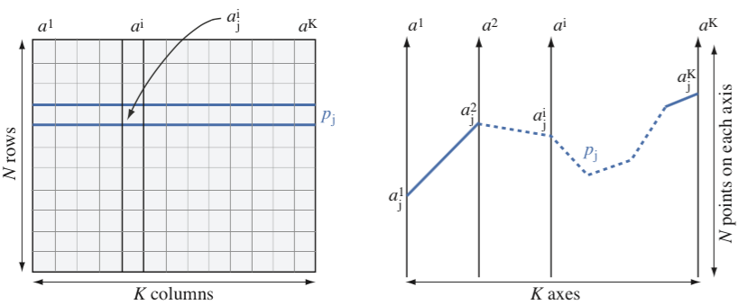

- `row`: horizontal line
- `column`: vertical line
- `column-column correlation`: not easy to see
- `row`: skewed polyline
- `column`: vertical line (permuted values)
- `column-column correlation`: easy to see

## Parallel coordinates in plotly

```python
wideTable["older"] = wideTable["older"].astype(int)           # exergame_parallel.ipynb
fig = px.parallel_coordinates(wideTable[wideTable.columns[5:]],color='older')
```

[interactive chart not shown]

- Highlight all rows (lines) passing through selection
- Drag and drop axis horizontally

## Parallel coordinates (ggplot)

```r
library(ggplot2)
library(data.table)
longTable = fread('../../data/exergamelf2.csv')
ggplot(data=longTable,aes(x=myVars,y=normVal)) +
    geom_line(aes(group=idrow,colour=older),alpha=0.5) +
    theme_bw()
```

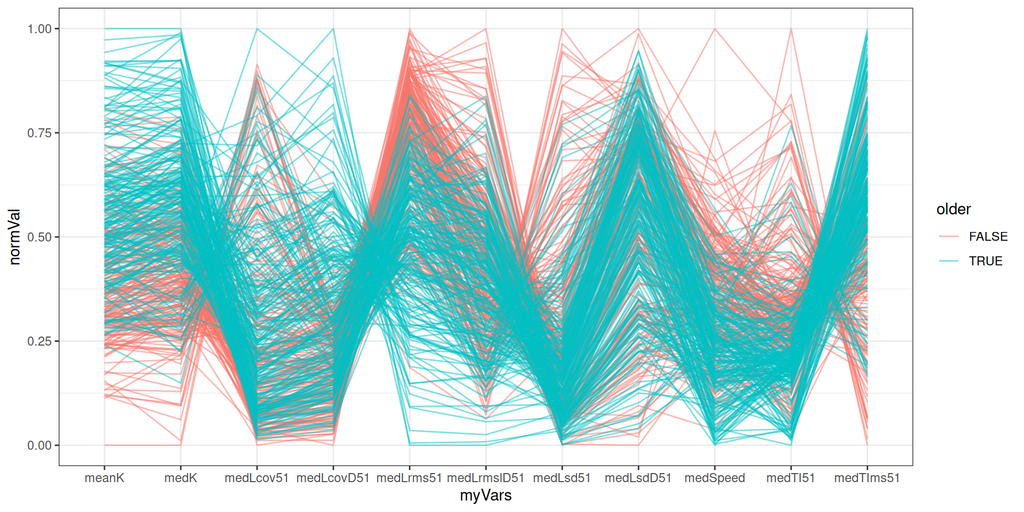

## Density based parallel coordinates

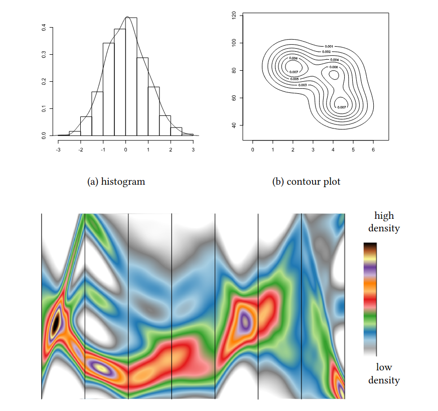

Source: [Visualization Techniques for Parallel Coordinates](https://elib.uni-stuttgart.de/bitstream/11682/6450/1/Thesis_JH_20130712_electronic_downsampled_web.pdf)

## Bundled parallel coordinates

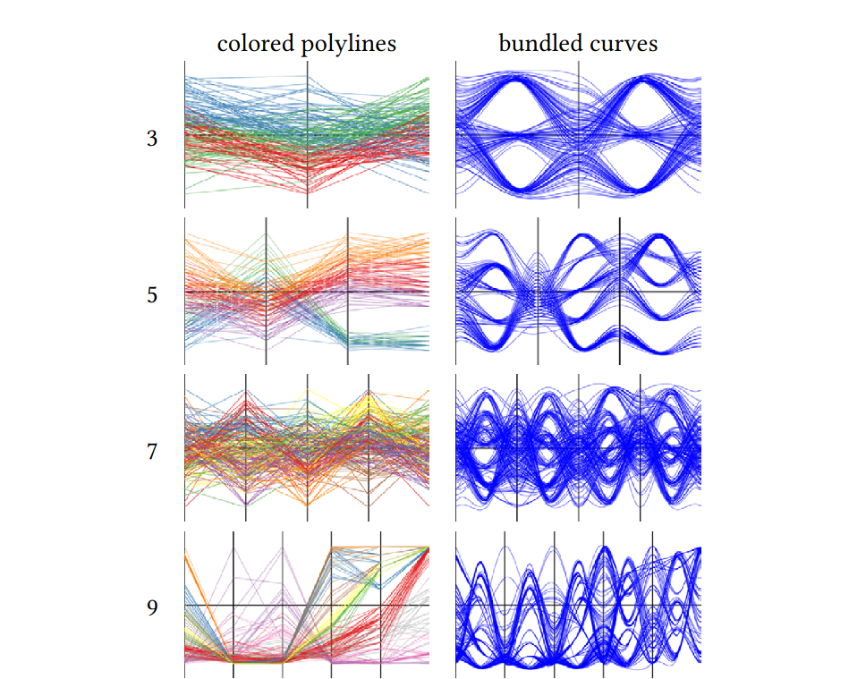

Source: [Visualization Techniques for Parallel Coordinates](https://elib.uni-stuttgart.de/bitstream/11682/6450/1/Thesis_JH_20130712_electronic_downsampled_web.pdf)

## Heatmap

- A heatmap displays a matrix of values as colored tiles.
- Each tile can be as small as a pixel.
- Typically: x = horizontal variable, y = vertical variable, color = intensity/value (z).
- Limited by the size/resolution of the screen.
- Color-shading functions are very sensitive to outliers.
- Useful for showing density, correlations, spatiotemporal intensity, and aggregated summaries.

## Measles heatmap source code

[Battling Infectious Diseases](https://graphics.wsj.com/infectious-diseases-and-vaccines/)

```python
import pandas as pd
import plotly.graph_objects as go

longTable = pd.read_csv('../../data/measlesCleaned.csv')
longTable = longTable[longTable.year > 1920]
# longTable.head()

fig = go.Figure(data=go.Heatmap(
        z=longTable['Measles_pop'],
        x=longTable['year'],
        y=longTable['State_Name'],
        xgap=2,
        ygap=2,
        colorscale=['#ddebf8','#0c9dc5','#44ae57','#fcd43d','#e59e26','#e48925','#e95034','#da4b31','#cf472e']));

fig.update_layout(
    # title='',
    # xaxis_nticks=40,
    autosize=False,width=1000,height=900);
```

Source code: `Measles_heatmap.ipynb`

## Measles heatmap

[interactive chart not shown]

## Shaded matrix from Loua (1873)

Summary of 40 separate maps of Paris showing 20 districts.

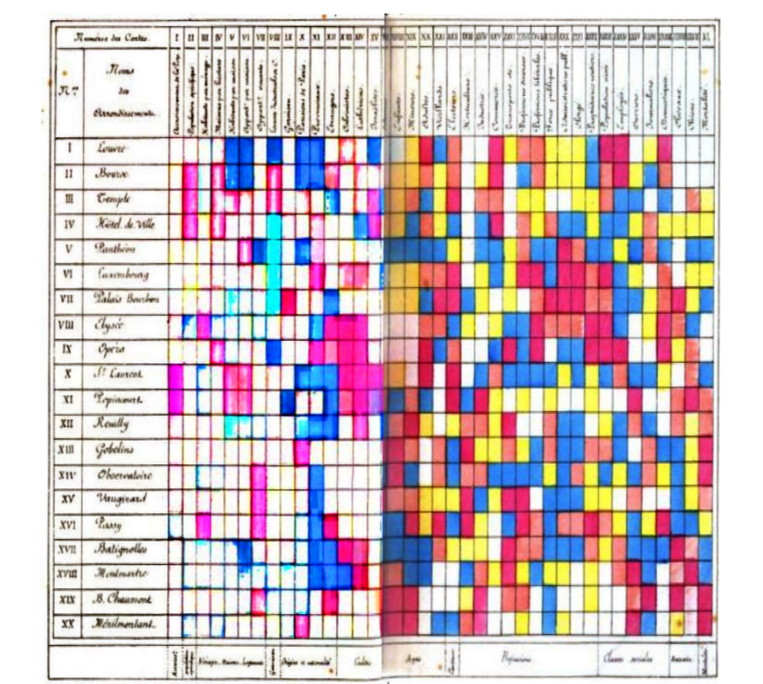

Source: The history of the cluster heatmap. Wilkinson and Friendly (2009).

## Scatterplots

- Show the relationship between two variables
- Can be used to visualize clusters
- Can be used to create matrix scatterplots
  - Works fine for a limited number of variables

## Speed vs. Curvature

```python
import pandas as pd
import plotly.express as px

df = pd.read_csv('../../data/exergamewf.csv')

# Ensure 'older' is categorical so Plotly uses distinct symbols
df['older'] = df['older'].astype(str)
df['Age'] = pd.to_numeric(df['Age'], errors='coerce')


# Create scatter plot
fig = px.scatter(
    df,
    x='meanK',
    y='medSpeed',
    color='Age',          # continuous color; use discrete colormap if Age is categorical
    symbol='older',       # different marker shapes per category in 'older'
    height=500,
    hover_data=['iSubj', 'trial'],  # optional extra hover info (adjust to your columns)
    color_continuous_scale='viridis', # or 'magma', 'plasma', etc.
    labels={'meanK': 'K', 'medSpeed': 'Speed', 'Age': 'Age', 'older': 'older'},
)

fig.update_traces(marker=dict(size=8, opacity=0.85));
fig.update_layout(template='plotly_white', legend_title_text='older');
```

## Speed vs. Curvature

[interactive chart not shown]

## Matrix scatterplot

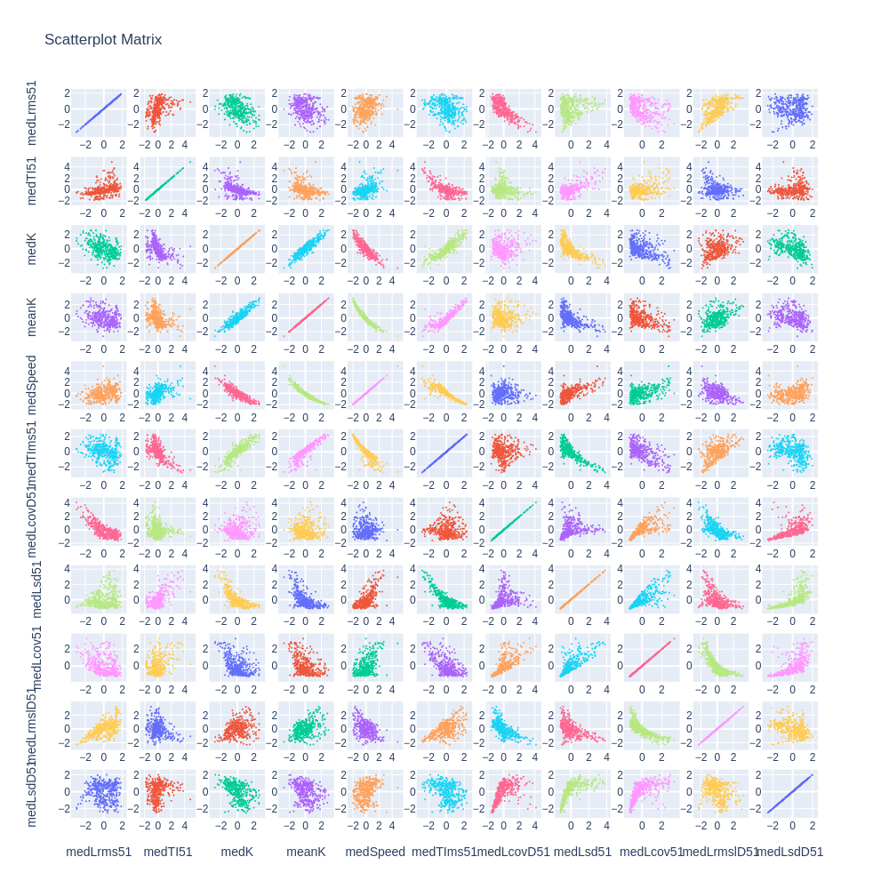

## Enhanced matrix scatterplot

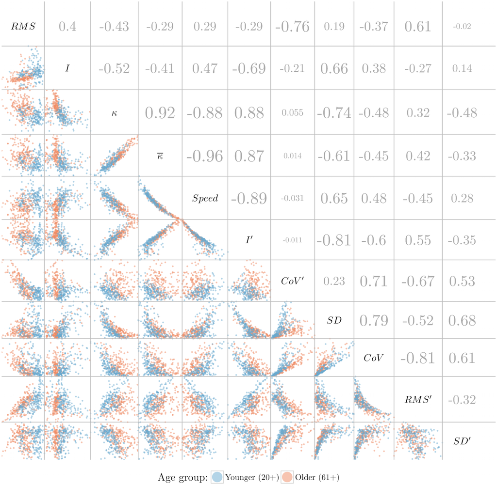

## Projections

- a row represents an n-dimensional point,
- a row can be represented/mapped as a 2D point
- point-to-point distance (in 2D) shows similarity of table rows (in nD)
- coloring points by one attribute can show groups

## Projections

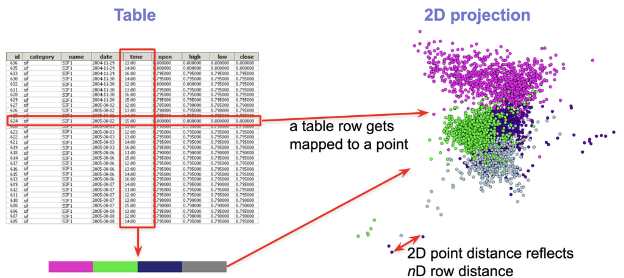

## PCA projection in R

```r
library(ggfortify)

wtable <- read.csv("../../data/exergamewf.csv")

# pca
tpca <- prcomp(wtable[,5:15],scale=TRUE)

# plot
fig <- autoplot(tpca, data = wtable, colour = 'older',
                loadings = TRUE, loadings.colour = 'blue',
                loadings.label = TRUE,
                loadings.label.size = 5
                ) +
    theme_bw()
```

## PCA projection

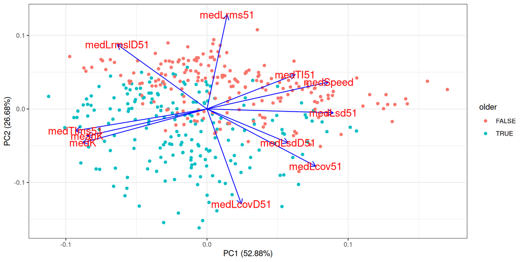

## Treemaps

- A space-filling visualization that represents a `hierarchy` as nested rectangles.
- Each rectangle’s area encodes a quantitative value (part → whole).
- Color encodes a second variable (categorical or continuous).
- Labels identify nodes; interaction (hover/zoom) helps reading details.

## Anatomy of a treemap

- `Root`: full slide area (single root or implicit “all”).
- `Branches`: nested rectangles for hierarchical levels (path argument).
- `Leaves`: final rectangles sized by the chosen numeric value.
- `Color`: additional metric (e.g., rate, average) mapped to a color scale.

## A pet shop treemap

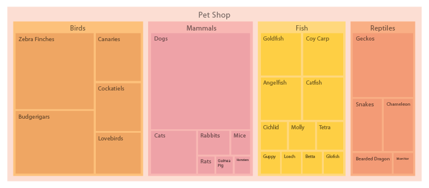

Source: [Datavizcatalogue](https://datavizcatalogue.com/methods/treemap.html)

## Visualizing the exergame data as a treemap

```python
# Importing the packages
import plotly.express as px
import pandas as pd
# Loading and displaying the data
tableRes = pd.read_csv('../../data/exergamewf.csv')

tableRes["Participants"] = "Participants" # in order to have a single root node
tableRes.head()
```

```
   iSubj  trial  Age  Decade  ...  medLrmslD51  medLsdD51  older  Participants
0      1      1   76       7  ...     1.259172   0.129068   True  Participants
1      1      2   76       7  ...     1.263366   0.105902   True  Participants
2      1      3   76       7  ...     0.782796   0.133917   True  Participants
3      1      4   76       7  ...     0.487570   0.108637   True  Participants
4      1      5   76       7  ...     0.646194   0.119610   True  Participants

[5 rows x 17 columns]
```

## Treemap source code

```python
fig = px.treemap(tableRes,
                    path=['Participants', 'iSubj', 'trial'],
                    values='Age',
                    color='medSpeed',
                    color_continuous_scale=['#d7191c','#fdae61','#ffffbf','#abd9e9','#2c7bb6']
                )

fig.update_layout(
                    autosize=False,
                    width=1000,
                    height=600
                );
```

### Treemap showing speed values per participant

```python
fig.show()
```

[interactive chart not shown]